# Making Gifs with Matplotlib and Recaman

This notebook is meant to be a tutorial on generating an animated gif using matplotlib. The subject to be animated is an implementation of the [Racaman Sequence](https://en.wikipedia.org/wiki/Recam%C3%A1n%27s_sequence).

Helpful Resources:

- [Recaman Sequence Numberphile Video](https://www.youtube.com/watch?v=FGC5TdIiT9U)
- [Python Implementation](https://www.geeksforgeeks.org/recamans-sequence/amp/)
- [Plotting](https://www.geeksforgeeks.org/recamans-sequence/amp/)

```python
import matplotlib.pyplot as plt
from matplotlib import patches
from matplotlib import animation
from matplotlib import rc
import os
from typing import List, Union
%matplotlib inline
from IPython.display import HTML
```

## Define the Sequence

First we need to create an implementation of the Recaman Sequence. Here the `set` object is used to maintain a list of values of `n`, that have already been seen. While a set (`sequence`) is a useful object to check for member presence (due to hashing), a list (`recaman_series`) is used to maintain sequence ordering.

```python
def recaman(n: int) -> List[int]:
    """
    Compute the values in the Recaman Sequence up to a N members
    Args:
        n (int): number of sequence members to compute

    Returns:
        recaman_series (list): The Recaman Sequence up to N members
    """

    # Check to see if the sequence count is <= 0
    if n <= 0 or not isinstance(n, int):
        raise ValueError(f'Invalid Input, must be positive integer')

    # initialize a set (monitor previous seen values) and a list (container for sequence results)
    sequence = {0}
    recaman_series = [0]

    previous_value = 0
    for i in range(1, n):
        # check backwards direction since the sequence must go back if possible
        current_value = previous_value - i
        # If the value is negative or already exists.
        if (current_value < 0 or current_value in sequence):
            current_value = previous_value + i

        sequence.add(current_value)
        recaman_series.append(current_value)
        previous_value = current_value  # move the current value forward
    return recaman_series
```

We want to grab a small set of the sequence to make sure it returns the expected results

```python
N = 15
print(f'The first {N} members of the Recaman Sequence are: {recaman(N)}')
```

```
The first 15 members of the Recaman Sequence are: [0, 1, 3, 6, 2, 7, 13, 20, 12, 21, 11, 22, 10, 23, 9]
```

## Plotting

In order to plot the sequence in the semi-circle style, we need to first be able to calculate the appropriate plot arcs. This is done using matplotlib's `patches` library to generate the appropriate arc segment for each member of the sequence.

```python
def compute_arcs(sequence: List[int]) -> List:
    """
    Compute each of the arc segments for each member of a Recaman Sequence
    to be plotted using matplotlib
    Args:
        sequence (list): A Recaman Sequence

    Returns:
        arcs (list): A collection of matplotlib arc segments for
            each member of the sequence

    """
    arcs = []
    for i in range(len(sequence) - 1):
        # midway point should be between sequence members on the x-axis
        arc_center = (0.5 * (sequence[i] + sequence[i + 1]), 0)
        # arc heigh and width is proportional to the sequence element number
        arc_width = abs(sequence[i + 1] - sequence[i])
        arc_height = abs(sequence[i + 1] - sequence[i])
        # slternate orientation of the arc (convex up or down)
        arc_angle = (pow(-1, i + 1) + 1) / 2 * 180
        # arc will always span 180 degrees
        start_angle = 180
        end_angle = 360
        # create an arc segment
        cur_arc = patches.Arc(
            arc_center,
            arc_width,
            arc_height,
            angle=arc_angle,
            theta1=start_angle,
            theta2=end_angle,
            linewidth=1,
            fill=False
        )
        arcs.append(cur_arc)
    return arcs
```

With the ability to calculate the arc segment for each member of the sequence, a figure can be plotted

```python
def plot_recaman(sequence: List[int]) -> None:
    """
    Plot a semi-circular representation of a Recaman Sequence
    Args:
        sequence (list): A Recaman Sequence

    Returns:
        N/A
    """

    # create the arcs associated with each sequence member
    arcs = compute_arcs(sequence)
    # create a figure and all each of the arc segments in order
    fig, ax = plt.subplots(figsize=(9.5, 6))
    for arc in arcs:
        ax.add_patch(arc)
    # set the plot limits to encompas the entire sequence
    buffer_factor = 1.1  # buffer to give the figure breathing room
    ax.set_xlim(-(buffer_factor - 1) * max(sequence), buffer_factor * max(sequence))
    ax.set_ylim(-0.5 * buffer_factor * len(sequence), 0.5 * buffer_factor * len(sequence))
    ax.set_aspect('equal')
    ax.set_title(f'Recaman Sequence\nN=({len(sequence)})')
    fig.tight_layout()
    plt.show()
```

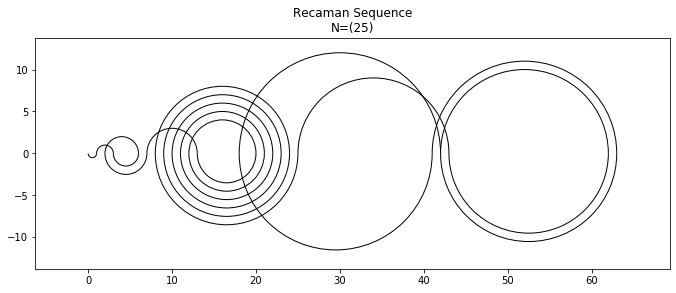

```python
N = 25
plot_recaman(recaman(N))
```

## Animated Gif

To add some interest to the plot, we can animate it so that each arc segment is drawn for each member of the sequence.

```python
def animate_recaman(sequence: List,
                    duration_sec: int = 5,
                    bitrate: int = 1000,
                    dpi: int = 100,
                    embedded: bool = False,
                    ) -> Union[str, HTML]:
    """
    Animate the plotting of a Recaman Sequence
    Args:
        sequence (list): Recaman sequence
        duration_sec (int): duration of the animation, determines frames per second (fps)
        bitrate (int): bits per second used to compress the output animation
        dpi (int): dots per inch of the resulting animtaion
        embedded (bool): flag to embed the animation as html5 (for use in a notebook)

    Returns:
        save_filename (str): The file name of the saved animation
        html_video (HTML): A HTML5 encoded video of the animation

    """
    fig, ax = plt.subplots(dpi=dpi)
    edge_factor = 1.05  # set a 5% buffer to give the graph breathing room
    # set the width of the plot to cover the sequence span while centering it
    ax.set_xlim(-(edge_factor - 1) * max(sequence), edge_factor * max(sequence))
    #set the height of the graph to cover the arcs
    ax.set_ylim(-0.5 * edge_factor * len(sequence), 0.5 * edge_factor * len(sequence))
    ax.set_aspect('equal')
    ax.set_title(f"Recaman's Squence\nN={len(sequence)}")
    # add a watermark to the figure
    fig.text(0.95, 0.05, '@BrentonMallen',
             fontsize=12, color='black',
             ha='right', va='bottom', alpha=0.75)

    # generate the arcs to plot
    arcs = compute_arcs(sequence)
    # calculate the fps based off desired duration
    fps = len(sequence) // duration_sec

    if embedded:

        def animate(i):
            """
            Function used to update the figure
            """
            return ax.add_patch(i),

        anim = animation.FuncAnimation(fig,
                                       animate,
                                       frames=arcs,
                                       interval=100,
                                       blit=True
                                      )
        plt.close()  # prevent the static figure from displaying (the final frame)
        html_video = HTML(anim.to_html5_video())
        return html_video

    GifWriter = animation.ImageMagickFileWriter(fps,
                                             bitrate=bitrate
                                             )
    save_filename = f'recaman_{len(sequence)}.gif'
    with GifWriter.saving(fig, save_filename, dpi=dpi):
        for arc in arcs:
            ax.add_patch(arc)
            GifWriter.grab_frame()
    return f'Animation saved to: {save_filename}'
```

## Embedding the Animation

To display the animation in this notebook, it has to be created as a HTML5 video and embedded. To do this, the `FuncAnimation` function is used. It differs from the `ImageMagickFileWriter` (used to save a Gif as a file) in that it requires a set of frames and a function to definte the animation.

In this case, `frames` in `FuncAnimation` is the list of arcs generated (an iterable) and the function `animate` is used to add each arc to the figure as it updates for each frame.

```python
# specify that we want the animation to be displayed using html5 (html is default)
rc('animation', html='html5')

animate_recaman(recaman(100), embedded=True)
```

[video not shown]

**Saving The Gif to File**

The `animate_recaman` function is written in a way that allows for saving the gif off to a file or converting it to an HTML5 video so that it can be embedded in a notebook (as seen here)

**Note:**

The `GifWriter` will generate temporary png files in the same directory for each frame and then combine those to generate the gif. If for some reason, the `GifWriter` fails, those files will remain and have to be manually deleted.